# Homework #4 Key

R Markdown

Due: 22 Jan 2020

# Concepts

Explain the sequence whereby a word file is created from a R Markdown document. What is the purpose of the YAML header?

1. Create a R Markdown document
2. The knitr library converts the R Markdown file into a Markdown document
3. The pandoc software converts Markdown files into a variety of document formats including HTML, PDF, and Microsoft word.

The YAML header sets up the document. It can include a title, author, and date as well as other options that are documented at [Bookdown](https://bookdown.org/yihui/rmarkdown/). For our purposes, the most important part of the YAML header is the specification of the output. We generally use html_document with code folding or Microsoft Word.

# Interpretation of R Markdown code

## New lines and paragraphs can be very confusing. This is one of the most inconsistent and confusing parts of R Markdown. `Creates text within a heading 2 tag`

When using R Markdown, you insert a new line by putting two spaces and a carriage return at the end of your text. `This line ends with a new line rather than a paragraph` A new paragraph requires two carriage returns. `Creates a new paragraph`

R Markdown allows you to have italics, bold, and code `Regular line of code with new paragraph`

- *italics* `Pair of asterisks create italics`
- **bold** `Double pair of asterisks create bold`
- `code`. (A monospaced font is usually used for code.) `The symbol used to create code chunks also delineates code`

## Include graphics `Header 2 text`

[figure not shown]

`Inserts a graph from a file. The file can be a local file on your own computer or a url reference to a file on the web.`

## You can create your own graphics like this one that compares highway mpg for different class and drive train combinations. `Header 2 text`

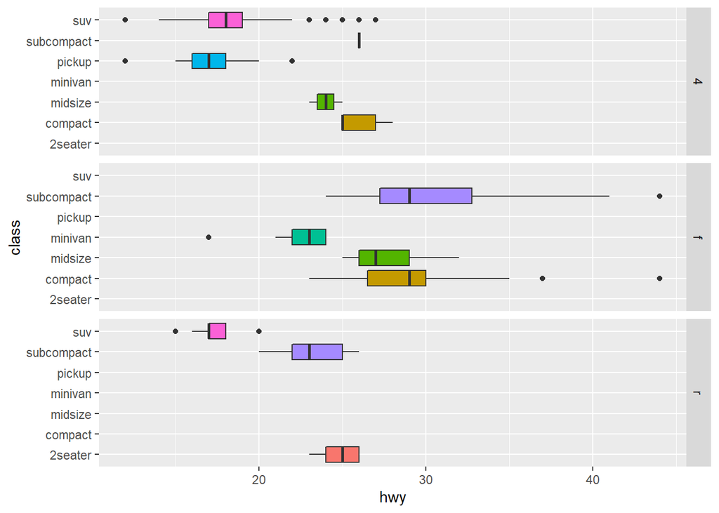

```r
ggplot(data = mpg, aes(x = class, y = hwy, fill = class)) +
  geom_boxplot(show.legend = FALSE) +
  coord_flip() +
  facet_grid(rows = vars(drv))
```

`The above is a display code chunk`

## You can also use include tables `Header 2 text`

Number of Students in *MPA 634: Data Science for Managers* `Regular text with part of text in italics`

| Department | Students |
| --- | --- |
| MBA | 2 |
| MISM | 6 |
| MPA | 8 |

`The above give lines create a table`

# Your code:

Write RMarkdown code that creates the following document. You don’t need another YAML header and setup R chunk because they are already part of this R Markdown document.

# This is an R Markdown Document

Parts of a distribution

- Range of values
- Probabilities or frequencies

We use the grammar of graphics and ggplot to create a series of density plots that compare the highway mpg for different types of drive trains.

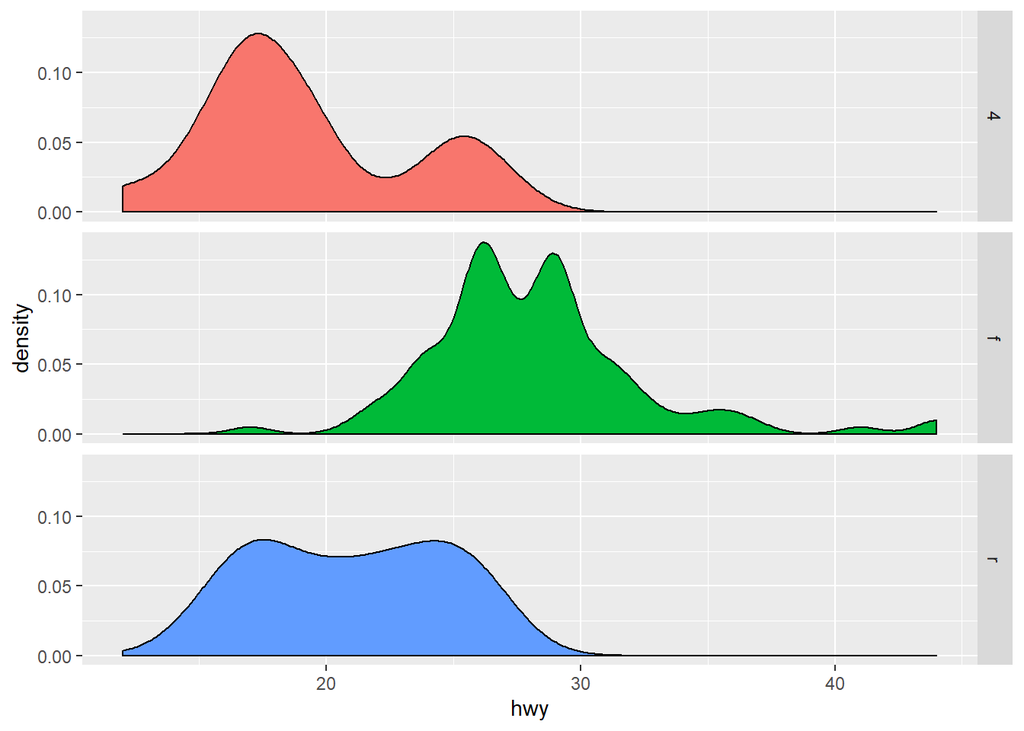

```r
ggplot(data = mpg, mapping = aes(x = hwy, fill = drv)) +
  geom_density(show.legend = FALSE) +
  facet_grid(rows = vars(drv))
```

1. The mean(mpg$hwy) function calculates the average of the hwy column in the mpg data frame.
2. The round(aNumber, 2) rounds the number to two decimal places.

An inline sentence is: “The average highway mileage for all cars is 23.44 miles per gallon.”